# IODS course project

### Performing MCA

The dimension 1-3 (Dim.1, Dim.2, Dim.3) explain 53,98% of the variance.  
The Dim.1 has the biggest eta2-values with variables “how” (0.710) and “where” (0.671). The Dim2 with “where”(0.673) and “how” (0.640), and the Dim.3 with “Sugar” (0.470) and Tea” (0.450).

The last plot shows that dimensions of the data with these variables are condensed rather poorly.

Different plotting options for example here: [http://www.sthda.com/english/articles/31-principal-component-methods-in-r-practical-guide/114-mca-multiple-correspondence-analysis-in-r-essentials/]

```r
mca <- MCA(tea_time, graph = FALSE) # multiple correspondence analysis

# summary of the model
summary(mca)
```

```
##
## Call:
## MCA(X = tea_time, graph = FALSE)
##
##
## Eigenvalues
##                        Dim.1   Dim.2   Dim.3   Dim.4   Dim.5   Dim.6   Dim.7
## Variance               0.329   0.299   0.235   0.205   0.189   0.152   0.107
## % of var.             20.592  18.686  14.698  12.807  11.792   9.489   6.679
## Cumulative % of var.  20.592  39.277  53.975  66.782  78.575  88.063  94.743
##                        Dim.8
## Variance               0.084
## % of var.              5.257
## Cumulative % of var. 100.000
##
## Individuals (the 10 first)
##                         Dim.1    ctr   cos2    Dim.2    ctr   cos2    Dim.3
## 1                    | -0.282  0.080  0.071 | -0.419  0.196  0.156 | -0.355
## 2                    | -0.075  0.006  0.005 | -0.332  0.123  0.100 | -0.921
## 3                    | -0.372  0.140  0.232 | -0.274  0.084  0.126 | -0.266
## 4                    | -0.579  0.340  0.537 | -0.361  0.145  0.209 |  0.300
## 5                    | -0.372  0.140  0.232 | -0.274  0.084  0.126 | -0.266
## 6                    | -0.372  0.140  0.232 | -0.274  0.084  0.126 | -0.266
## 7                    | -0.372  0.140  0.232 | -0.274  0.084  0.126 | -0.266
## 8                    | -0.075  0.006  0.005 | -0.332  0.123  0.100 | -0.921
## 9                    |  0.187  0.036  0.026 |  0.967  1.043  0.698 | -0.127
## 10                   |  0.485  0.238  0.128 |  0.909  0.922  0.450 | -0.782
##                         ctr   cos2
## 1                     0.178  0.112 |
## 2                     1.202  0.772 |
## 3                     0.100  0.118 |
## 4                     0.128  0.144 |
## 5                     0.100  0.118 |
## 6                     0.100  0.118 |
## 7                     0.100  0.118 |
## 8                     1.202  0.772 |
## 9                     0.023  0.012 |
## 10                    0.867  0.332 |
##
## Categories (the 10 first)
```

[output cut: 15 more lines]

```
## tea bag                0.298  -9.435 |  -0.122   0.719   0.020  -2.416 |
## tea bag+unpackaged     0.629  13.710 |  -0.001   0.000   0.000  -0.009 |
## unpackaged             0.090  -5.183 |   0.579   3.420   0.046   3.697 |
## No.sugar               0.014   2.057 |  -0.663  19.337   0.470 -11.860 |
## sugar                  0.014  -2.057 |   0.709  20.671   0.470  11.860 |
## chain store            0.273  -9.033 |  -0.167   1.526   0.050  -3.861 |
## chain store+tea shop   0.641  13.844 |   0.048   0.050   0.001   0.487 |
##
## Categorical variables (eta2)
##                        Dim.1 Dim.2 Dim.3
## Tea                  | 0.179 0.070 0.450 |
## how                  | 0.710 0.640 0.049 |
## sugar                | 0.088 0.014 0.470 |
## where                | 0.671 0.673 0.108 |
## lunch                | 0.000 0.097 0.099 |
```

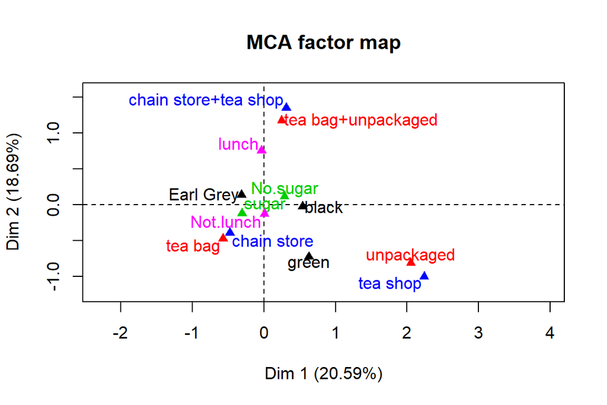

```r
# MCA factor map
plot(mca, invisible=c("ind"), habillage = "quali", graph.type = "classic")
```

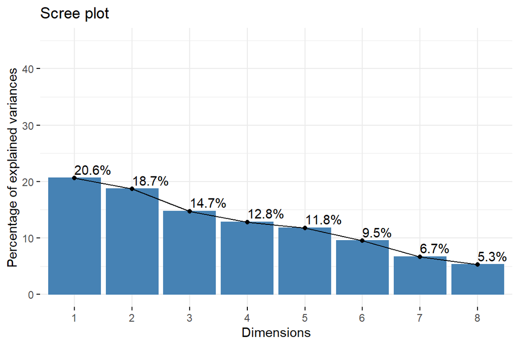

```r
# alternative plot with percentages of explained variances
library("factoextra")
fviz_screeplot(mca, addlabels = TRUE, ylim = c(0, 45))
```

```r
date()
```

```
## [1] "Sun Dec 12 11:44:41 2021"
```

```r
library(tidyverse)
library(dplyr)
library(ggplot2)
```

# Chapter 6: Analysis of longitudinal data

## 6.1 RATS

### The data

The RATS data is from a nutrition study conducted in three groups of rats (Crowder and Hand, 1990). The groups were put on different diets, and each rats body weight (grams) was recorded repeatedly over a 9-week period. (MABS, p .174) The variable “Time” = days.

```r
# read the RATS data
RATS <- read.table("https://raw.githubusercontent.com/KimmoVehkalahti/MABS/master/Examples/data/rats.txt", header = TRUE, sep = '\t')

# Factor variables ID and Group
RATS$ID <- factor(RATS$ID)
RATS$Group <- factor(RATS$Group)

# Glimpse the data
glimpse(RATS)
```

```
## Rows: 16
## Columns: 13
## $ ID    <fct> 1, 2, 3, 4, 5, 6, 7, 8, 9, 10, 11, 12, 13, 14, 15, 16
## $ Group <fct> 1, 1, 1, 1, 1, 1, 1, 1, 2, 2, 2, 2, 3, 3, 3, 3
## $ WD1   <int> 240, 225, 245, 260, 255, 260, 275, 245, 410, 405, 445, 555, 470,~
## $ WD8   <int> 250, 230, 250, 255, 260, 265, 275, 255, 415, 420, 445, 560, 465,~
## $ WD15  <int> 255, 230, 250, 255, 255, 270, 260, 260, 425, 430, 450, 565, 475,~
## $ WD22  <int> 260, 232, 255, 265, 270, 275, 270, 268, 428, 440, 452, 580, 485,~
## $ WD29  <int> 262, 240, 262, 265, 270, 275, 273, 270, 438, 448, 455, 590, 487,~
## $ WD36  <int> 258, 240, 265, 268, 273, 277, 274, 265, 443, 460, 455, 597, 493,~
## $ WD43  <int> 266, 243, 267, 270, 274, 278, 276, 265, 442, 458, 451, 595, 493,~
## $ WD44  <int> 266, 244, 267, 272, 273, 278, 271, 267, 446, 464, 450, 595, 504,~
## $ WD50  <int> 265, 238, 264, 274, 276, 284, 282, 273, 456, 475, 462, 612, 507,~
## $ WD57  <int> 272, 247, 268, 273, 278, 279, 281, 274, 468, 484, 466, 618, 518,~
## $ WD64  <int> 278, 245, 269, 275, 280, 281, 284, 278, 478, 496, 472, 628, 525,~
```

```r
# Convert data to long form
RATSL <- RATS %>%
  gather(key = WD, value = Weight, -ID, -Group) %>%
  mutate(Time = as.integer(substr(WD,3,4)))

# Glimpse the data
glimpse(RATSL)
```

```
## Rows: 176
## Columns: 5
## $ ID     <fct> 1, 2, 3, 4, 5, 6, 7, 8, 9, 10, 11, 12, 13, 14, 15, 16, 1, 2, 3,~
## $ Group  <fct> 1, 1, 1, 1, 1, 1, 1, 1, 2, 2, 2, 2, 3, 3, 3, 3, 1, 1, 1, 1, 1, ~
## $ WD     <chr> "WD1", "WD1", "WD1", "WD1", "WD1", "WD1", "WD1", "WD1", "WD1", ~
## $ Weight <int> 240, 225, 245, 260, 255, 260, 275, 245, 410, 405, 445, 555, 470~
## $ Time   <int> 1, 1, 1, 1, 1, 1, 1, 1, 1, 1, 1, 1, 1, 1, 1, 1, 8, 8, 8, 8, 8, ~
```

### RATS plots

```r
# The dimensions of the data
dim(RATSL)
```

```
## [1] 176   5
```

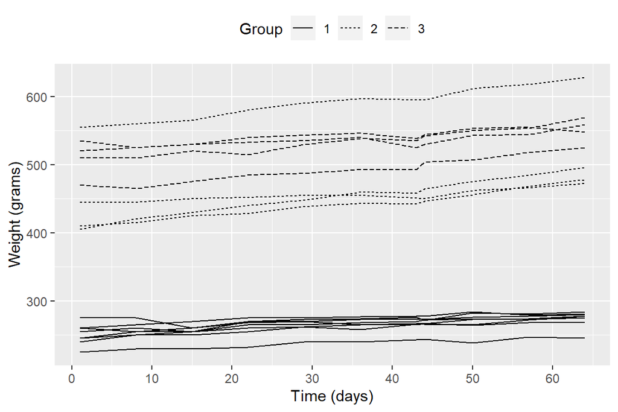

```r
# The individual rat growth profiles (non-standardized)
ggplot(RATSL, aes(x = Time, y = Weight, group = ID)) +
  geom_line(aes(linetype = Group)) +
  scale_x_continuous(name = "Time (days)", breaks = seq(0, 60, 10)) +
  scale_y_continuous(name = "Weight (grams)") +
  theme(legend.position = "top")
```

```r
colnames(RATSL)
```

```
## [1] "ID"     "Group"  "WD"     "Weight" "Time"
```

```r
View(RATSL)

# Standardising the variable RATSL
RATSL <- RATSL %>%
  group_by(Time) %>%
  mutate(std_weight = (Weight - mean(Weight))/sd(Weight)) %>%
  ungroup()

# Glimpse the data
glimpse(RATSL)
```

```
## Rows: 176
## Columns: 6
## $ ID         <fct> 1, 2, 3, 4, 5, 6, 7, 8, 9, 10, 11, 12, 13, 14, 15, 16, 1, 2~
## $ Group      <fct> 1, 1, 1, 1, 1, 1, 1, 1, 2, 2, 2, 2, 3, 3, 3, 3, 1, 1, 1, 1,~
## $ WD         <chr> "WD1", "WD1", "WD1", "WD1", "WD1", "WD1", "WD1", "WD1", "WD~
## $ Weight     <int> 240, 225, 245, 260, 255, 260, 275, 245, 410, 405, 445, 555,~
## $ Time       <int> 1, 1, 1, 1, 1, 1, 1, 1, 1, 1, 1, 1, 1, 1, 1, 1, 8, 8, 8, 8,~
## $ std_weight <dbl> -1.0011429, -1.1203857, -0.9613953, -0.8421525, -0.8819001,~
```

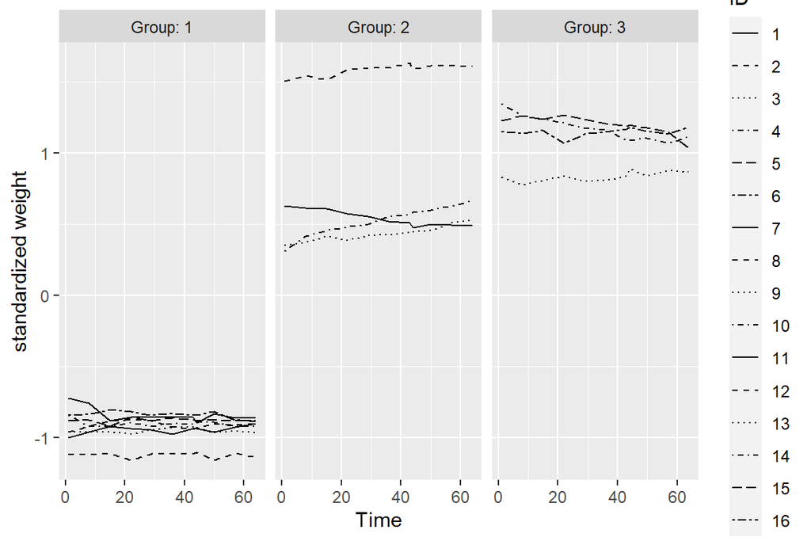

```r
View(RATSL)

# The standardized RATSL weight plot by group, time and ID
ggplot(RATSL, aes(x = Time, y = std_weight, linetype = ID)) +
  geom_line() +
  scale_linetype_manual(values = rep(1:10, times=11)) +
  facet_grid(. ~ Group, labeller = label_both) +
  scale_y_continuous(name = "standardized weight")
```

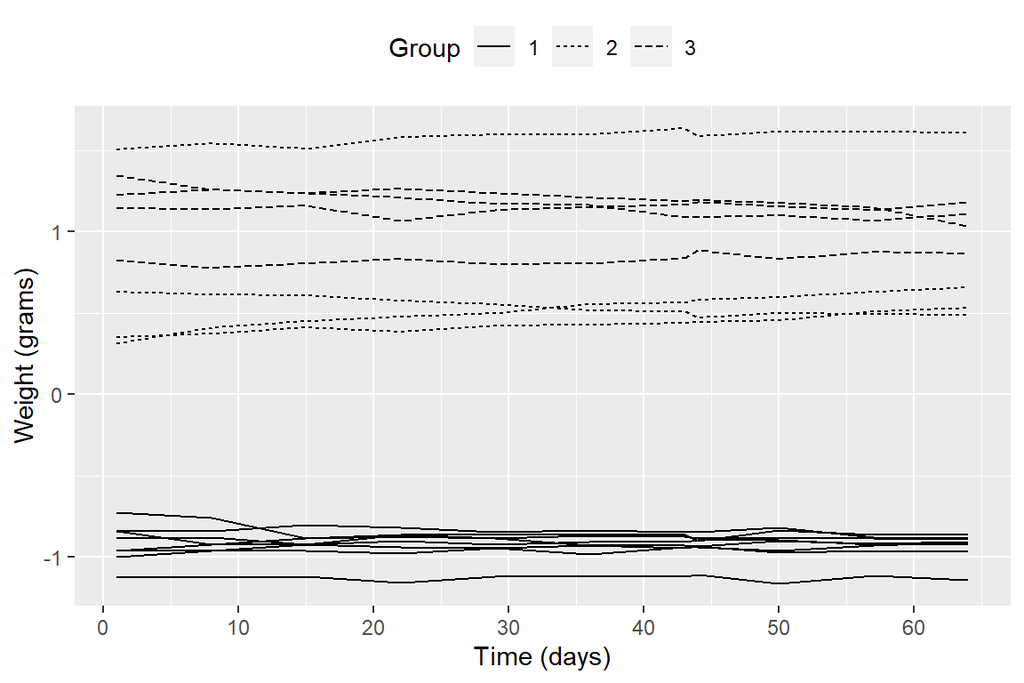

```r
# The individual rat growth profiles (standardized)
ggplot(RATSL, aes(x = Time, y = std_weight, group = ID)) +
  geom_line(aes(linetype = Group)) +
  scale_x_continuous(name = "Time (days)", breaks = seq(0, 60, 10)) +
  scale_y_continuous(name = "Weight (grams)") +
  theme(legend.position = "top")
```

## 6.2 Summary Measure Analysis

```r
# Number of measurement days, baseline (day 1) included
n <- RATSL$Time %>% unique() %>% length()
n # =11
```

```
## [1] 11
```

```r
# Summary data with mean and standard error of weight grouped by Group and Time
RATSS <- RATSL %>%
  group_by(Group, Time) %>%
  summarise(mean = mean(Weight), se = sd(Weight)/sqrt(n) ) %>%
  ungroup()
# Glimpse the data
glimpse(RATSS)
```

```
## Rows: 33
## Columns: 4
## $ Group <fct> 1, 1, 1, 1, 1, 1, 1, 1, 1, 1, 1, 2, 2, 2, 2, 2, 2, 2, 2, 2, 2, 2~
## $ Time  <int> 1, 8, 15, 22, 29, 36, 43, 44, 50, 57, 64, 1, 8, 15, 22, 29, 36, ~
## $ mean  <dbl> 250.625, 255.000, 254.375, 261.875, 264.625, 265.000, 267.375, 2~
## $ se    <dbl> 4.589478, 3.947710, 3.460116, 4.100800, 3.333956, 3.552939, 3.30~
```

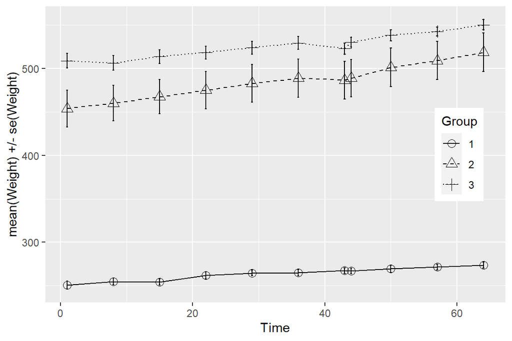

```r
View(RATSS)

# Mean response proﬁles for the three groups in the RATS data
ggplot(RATSS, aes(x = Time, y = mean, linetype = Group, shape = Group)) +
  geom_line() +
  scale_linetype_manual(values = c(1,2,3)) +
  geom_point(size=3) +
  scale_shape_manual(values = c(1,2,3)) +
  geom_errorbar(aes(ymin = mean - se, ymax = mean + se, linetype="1"), width=0.3) +
  theme(legend.position = c(0.9,0.5)) +
  scale_y_continuous(name = "mean(Weight) +/- se(Weight)")
```

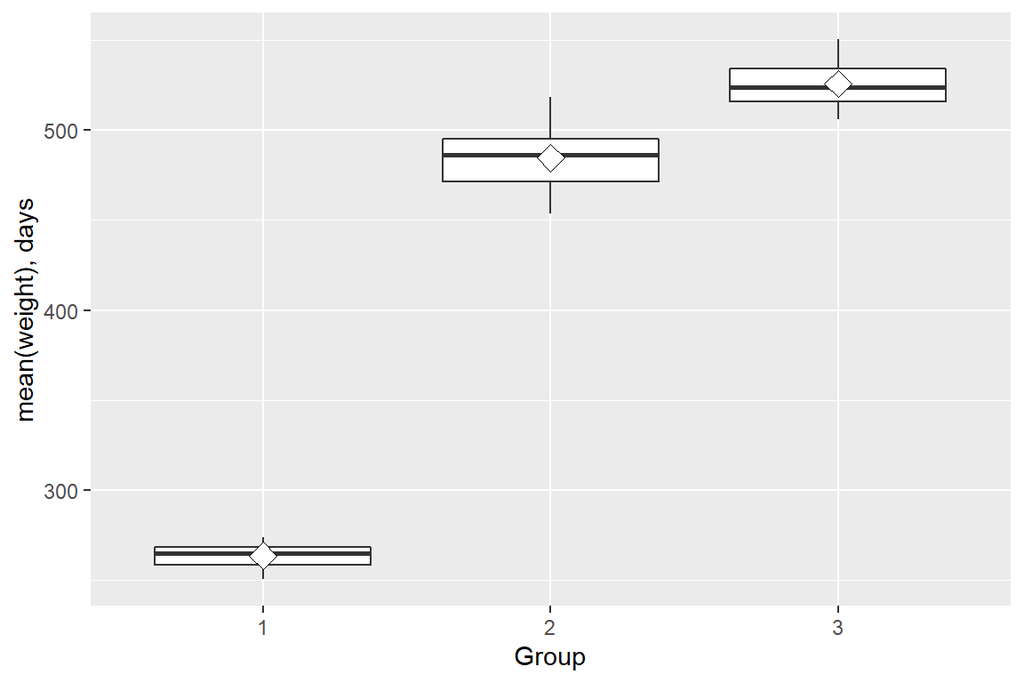

```r
# A boxplot of the mean versus group
ggplot(RATSS, aes(x = Group, y = mean)) +
  geom_boxplot() +
  stat_summary(fun = "mean", geom = "point", shape=23, size=4, fill = "white") +
  scale_y_continuous(name = "mean(weight), days")
```

### ANOVA

The results of the ANOVA indicate that the differences between the groups were statistically significant.

```r
# Creating a summary data by Group and ID with mean as the summary variable (ignoring baseline time 1).
RATSL8S <- RATSL %>%
  filter(Time > "1") %>%
  group_by(Group) %>%
  summarise( Time = Time,
             mean=mean(Weight) ) %>%
  ungroup()
# Glimpse the data
glimpse(RATSL8S)
```

```
## Rows: 160
## Columns: 3
## $ Group <fct> 1, 1, 1, 1, 1, 1, 1, 1, 1, 1, 1, 1, 1, 1, 1, 1, 1, 1, 1, 1, 1, 1~
## $ Time  <int> 8, 8, 8, 8, 8, 8, 8, 8, 15, 15, 15, 15, 15, 15, 15, 15, 22, 22, ~
## $ mean  <dbl> 265.025, 265.025, 265.025, 265.025, 265.025, 265.025, 265.025, 2~
```

```r
View(RATSL8S)

# Add the baseline from the original data as a new variable to the summary data
View(RATS)

RATS2 <- RATS %>%
  gather(key = WD, value = Weight, -ID, -Group)
View(RATS2)

RATSL8S <- RATSL8S %>%
  mutate(baseline = RATS2$WD1)

glimpse(RATSL8S)
```

```
## Rows: 160
## Columns: 3
## $ Group <fct> 1, 1, 1, 1, 1, 1, 1, 1, 1, 1, 1, 1, 1, 1, 1, 1, 1, 1, 1, 1, 1, 1~
## $ Time  <int> 8, 8, 8, 8, 8, 8, 8, 8, 15, 15, 15, 15, 15, 15, 15, 15, 22, 22, ~
## $ mean  <dbl> 265.025, 265.025, 265.025, 265.025, 265.025, 265.025, 265.025, 2~
```

```r
View(RATSL8S)

# Fit the linear model with the mean as the response
fit <- lm(mean ~ Group + Time, data = RATSL8S)

# Compute the analysis of variance table for the fitted model with anova()
anova(fit)
```

```
## Analysis of Variance Table
##
## Response: mean
##            Df  Sum Sq Mean Sq    F value Pr(>F)
## Group       2 2386197 1193099 2.6697e+30 <2e-16 ***
## Time        1       0       0 2.4748e+00 0.1177
## Residuals 156       0       0
## ---
## Signif. codes:  0 '***' 0.001 '**' 0.01 '*' 0.05 '.' 0.1 ' ' 1
```

## 6.3 BPRS

The data consists of 40 male subjects, that were randomly assigned to one of two treatment groups and each subject was rated on the brief psychiatric rating scale (BPRS) measured before treatment began (week 0), and then at weekly intervals for eight weeks. The BPRS assesses the level of 18 symptom constructs, with scale 1 (not present) - 7 (extremely severe). (MABS, p. 157)

### The data

```r
# Read the BPRS data
BPRS <- read.table("https://raw.githubusercontent.com/KimmoVehkalahti/MABS/master/Examples/data/BPRS.txt", sep  =" ", header = T)

# Look at the (column) names and structure of BPRS
names(BPRS)
```

```
##  [1] "treatment" "subject"   "week0"     "week1"     "week2"     "week3"
##  [7] "week4"     "week5"     "week6"     "week7"     "week8"
```

```r
str(BPRS)
```

```
## 'data.frame':    40 obs. of  11 variables:
##  $ treatment: int  1 1 1 1 1 1 1 1 1 1 ...
##  $ subject  : int  1 2 3 4 5 6 7 8 9 10 ...
##  $ week0    : int  42 58 54 55 72 48 71 30 41 57 ...
##  $ week1    : int  36 68 55 77 75 43 61 36 43 51 ...
##  $ week2    : int  36 61 41 49 72 41 47 38 39 51 ...
##  $ week3    : int  43 55 38 54 65 38 30 38 35 55 ...
##  $ week4    : int  41 43 43 56 50 36 27 31 28 53 ...
##  $ week5    : int  40 34 28 50 39 29 40 26 22 43 ...
##  $ week6    : int  38 28 29 47 32 33 30 26 20 43 ...
##  $ week7    : int  47 28 25 42 38 27 31 25 23 39 ...
##  $ week8    : int  51 28 24 46 32 25 31 24 21 32 ...
```

```r
BPRS$treatment <- factor(BPRS$treatment)
BPRS$subject <- factor(BPRS$subject)

# Adding individual IDs
BPRS$ID <- seq.int(nrow(BPRS))
glimpse(BPRS)
```

```
## Rows: 40
## Columns: 12
## $ treatment <fct> 1, 1, 1, 1, 1, 1, 1, 1, 1, 1, 1, 1, 1, 1, 1, 1, 1, 1, 1, 1, ~
## $ subject   <fct> 1, 2, 3, 4, 5, 6, 7, 8, 9, 10, 11, 12, 13, 14, 15, 16, 17, 1~
## $ week0     <int> 42, 58, 54, 55, 72, 48, 71, 30, 41, 57, 30, 55, 36, 38, 66, ~
## $ week1     <int> 36, 68, 55, 77, 75, 43, 61, 36, 43, 51, 34, 52, 32, 35, 68, ~
## $ week2     <int> 36, 61, 41, 49, 72, 41, 47, 38, 39, 51, 34, 49, 36, 36, 65, ~
## $ week3     <int> 43, 55, 38, 54, 65, 38, 30, 38, 35, 55, 41, 54, 31, 34, 49, ~
## $ week4     <int> 41, 43, 43, 56, 50, 36, 27, 31, 28, 53, 36, 48, 25, 25, 36, ~
## $ week5     <int> 40, 34, 28, 50, 39, 29, 40, 26, 22, 43, 36, 43, 25, 27, 32, ~
## $ week6     <int> 38, 28, 29, 47, 32, 33, 30, 26, 20, 43, 38, 37, 21, 25, 27, ~
## $ week7     <int> 47, 28, 25, 42, 38, 27, 31, 25, 23, 39, 36, 36, 19, 26, 30, ~
## $ week8     <int> 51, 28, 24, 46, 32, 25, 31, 24, 21, 32, 36, 31, 22, 26, 37, ~
## $ ID        <int> 1, 2, 3, 4, 5, 6, 7, 8, 9, 10, 11, 12, 13, 14, 15, 16, 17, 1~
```

```r
# Converting to long form
BPRSL <-  BPRS %>% gather(key = weeks, value = bprs, -treatment, -subject, -ID)
glimpse(BPRSL)
```

```
## Rows: 360
## Columns: 5
## $ treatment <fct> 1, 1, 1, 1, 1, 1, 1, 1, 1, 1, 1, 1, 1, 1, 1, 1, 1, 1, 1, 1, ~
## $ subject   <fct> 1, 2, 3, 4, 5, 6, 7, 8, 9, 10, 11, 12, 13, 14, 15, 16, 17, 1~
## $ ID        <int> 1, 2, 3, 4, 5, 6, 7, 8, 9, 10, 11, 12, 13, 14, 15, 16, 17, 1~
## $ weeks     <chr> "week0", "week0", "week0", "week0", "week0", "week0", "week0~
## $ bprs      <int> 42, 58, 54, 55, 72, 48, 71, 30, 41, 57, 30, 55, 36, 38, 66, ~
```

```r
# Extract the week number
BPRSL <-  BPRSL %>% mutate(week = as.integer(substr(weeks,5,5)))

# Take a glimpse at the BPRSL data
glimpse(BPRSL)
```

```
## Rows: 360
## Columns: 6
## $ treatment <fct> 1, 1, 1, 1, 1, 1, 1, 1, 1, 1, 1, 1, 1, 1, 1, 1, 1, 1, 1, 1, ~
## $ subject   <fct> 1, 2, 3, 4, 5, 6, 7, 8, 9, 10, 11, 12, 13, 14, 15, 16, 17, 1~
## $ ID        <int> 1, 2, 3, 4, 5, 6, 7, 8, 9, 10, 11, 12, 13, 14, 15, 16, 17, 1~
## $ weeks     <chr> "week0", "week0", "week0", "week0", "week0", "week0", "week0~
## $ bprs      <int> 42, 58, 54, 55, 72, 48, 71, 30, 41, 57, 30, 55, 36, 38, 66, ~
## $ week      <int> 0, 0, 0, 0, 0, 0, 0, 0, 0, 0, 0, 0, 0, 0, 0, 0, 0, 0, 0, 0, ~
```

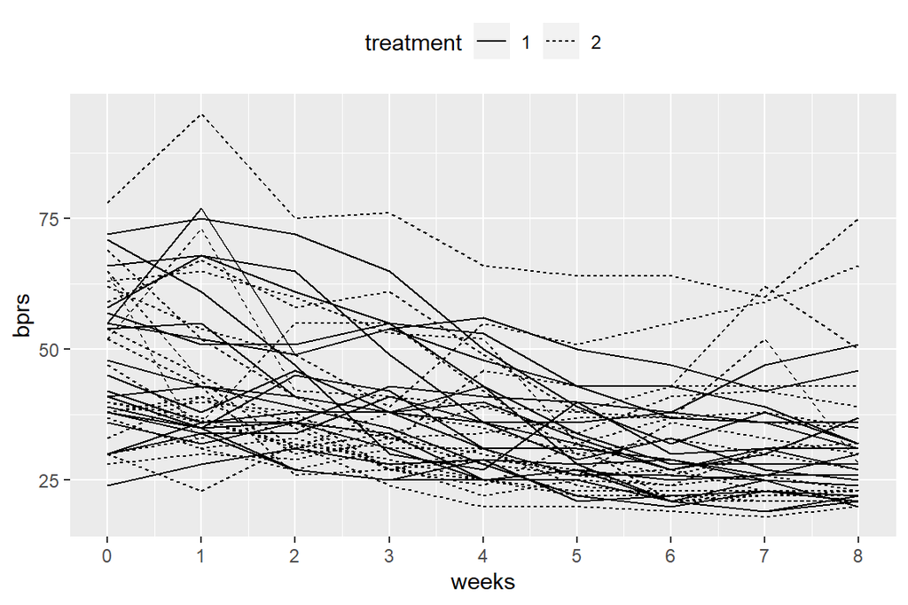

```r
View(BPRSL)

# Plot of the bprs values by ID's and measurement times (weeks)
ggplot(BPRSL, aes(x = week, y = bprs, group = ID)) +
  geom_line(aes(linetype = treatment)) +
  scale_x_continuous(name = "weeks", breaks = seq(0,8)) +
  scale_y_continuous(name = "bprs") +
  theme(legend.position = "top")
```

### Standardizing the data

```r
# Standardise the variable bprs
BPRSL <- BPRSL %>%
  group_by(week) %>%
  mutate(stdbprs = (bprs - mean(bprs))/sd(bprs) ) %>%
  ungroup()

# Glimpse the data
glimpse(BPRSL)
```

```
## Rows: 360
## Columns: 7
## $ treatment <fct> 1, 1, 1, 1, 1, 1, 1, 1, 1, 1, 1, 1, 1, 1, 1, 1, 1, 1, 1, 1, ~
## $ subject   <fct> 1, 2, 3, 4, 5, 6, 7, 8, 9, 10, 11, 12, 13, 14, 15, 16, 17, 1~
## $ ID        <int> 1, 2, 3, 4, 5, 6, 7, 8, 9, 10, 11, 12, 13, 14, 15, 16, 17, 1~
## $ weeks     <chr> "week0", "week0", "week0", "week0", "week0", "week0", "week0~
## $ bprs      <int> 42, 58, 54, 55, 72, 48, 71, 30, 41, 57, 30, 55, 36, 38, 66, ~
## $ week      <int> 0, 0, 0, 0, 0, 0, 0, 0, 0, 0, 0, 0, 0, 0, 0, 0, 0, 0, 0, 0, ~
## $ stdbprs   <dbl> -0.4245908, 0.7076513, 0.4245908, 0.4953559, 1.6983632, 0.00~
```